# esopianetiProsa

Lorenzo Bellina

6/20/2020

## UNO STUDIO SUGLI ESOPIANETI

Partendo dal dataset degli esopianeti fornitoci dalla NASA (https://exoplanetarchive.ipac.caltech.edu/cgi-bin/TblView/nph-tblView?app=ExoTbls&config=PS) è possibile svolgere una ricerca, seppur superficiale, di pianeti che potrebbero avere alcune condizioni necessarie per lo sviluppo di organismi viventi.

Per ogni pianeta riportato sono definite diverse caratteristiche quali la misura del raggio, il peso, il semiasse orbitale e molte altre per un totale maggiore di 200 specifiche. Gli esopianeti scoperti fino ad oggi sono migliaia ma la maggior parte di questi non è accomunabile alla Terra. L’obiettivo dell’analisi da me proposta è quello di cercare quali, tra i pianeti riportati nel database della NASA, possa somigliare il più possibile al nostro e quindi, teoricamente ospitare forme di vita di ogni genere.

## STRUTTURA DELL’ANALISI

L’analisi infatti si basa su:

- una prima grossolana selezione di esopianeti
- un successivo confronto tra questi
- una conseguente selezione degli elementi migliori

## PRIMA SELEZIONE

Gli esopianeti scoperti sino ad oggi sono migliaia ma non tutti sembrano adatti ad ospitare organismi viventi. Sono infatti necessarie alcune restrizioni volte ad escludere i pianeti troppo diversi dalla Terra:

- $raggio < 5 * radT , raggio > 0.25 * radT$
- $massa < 5 * massT , massa > 0.25 * massT$

I risultati di questa prima selezione vengono rappresentati nel seguente animation plot all’interno del quale compaiono a seconda dell’anno di scoperta, collocandosi più o meno vicini alla bisettrice del quadrante, ovvero in base alla somiglianza con la Terra, elemento per cui vengono classificati.

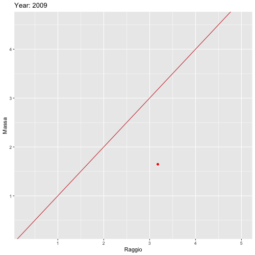

## I CASI MIGLIORI

Vengono dunque presi in considerazione solamente i casi migliori rappresentati in un grafico che li posiziona in base all’anno di scoperta e al rapporto tra massa e raggio in relazione al campione terrestre. Ad ognuno dei punti risultanti è affiliata una label indicante il nome del pianeta che esso rappresenta.

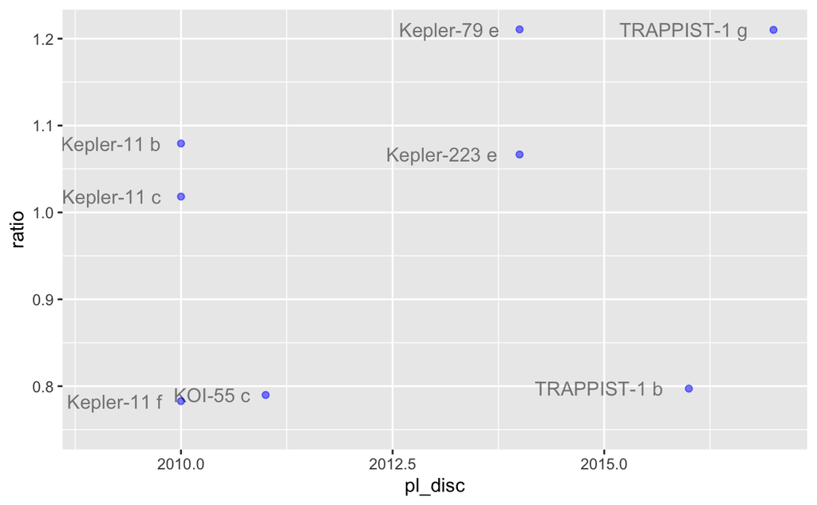

Notiamo così che due tra questi pianeti sono estramamente più vicini a noi. Questi appartengono allo stesso sistema: **TRAPPIST-1**.

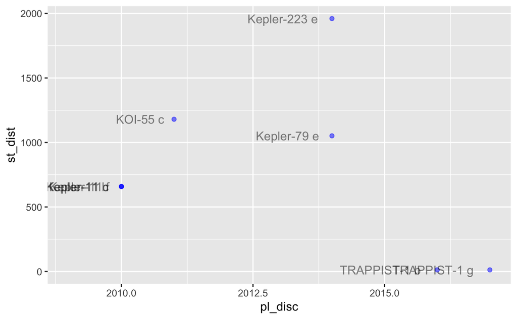

## TRAPPIST-1

Recuperiamo dunque i dati relativi all’intero sistema presente nel database iniziale per osservarne alcune caratteristiche. Purtroppo questo ci forniscce solo alcuni dettagli specifici tra cui però non ne compare uno essenziale: il tipo di rotazione, che, soprattutto in questo caso, diventa un dettaglio di assoluta rilevanza.

Entrambi infatti sono caratterizzati da una rotazione sincrona e quindi mostrano sempre la stessa faccia alla stella dividendosi in tre zone ben precise: una parte sempre a contatto con la luce della stella e di conseguenza molto calda, la parte ad essa opposta dominata dal ghiaccio e la zona intermedia tra esse nella quale grazie ai possibili oceani potrebbero abitare diverse forme di vita. Le temperature delle facce, sebbene in maniera opposta, sono estreme e rendono impossibile la vita nelle regioni più esposte (e allo stesso modo meno esposte) all’illuminazione della stella. Questo fenomeno fa sì che le uniche zone possibili in cui potrebbero essersi originate delle forme di vita siano i territori intermedi alle due facce.

## PARAGONE TRA I DUE SISTEMI

Confrontando questo al sistema solare si può notare come alcuni pianeti appartenenti a TRAPPIST-1 abbiano dimensioni simili ai nostri vicini, ad esclusione di Giove e Saturno in quanto troppo grandi. Come nel grafico relativo agli esopianeti è presente una retta sulla quale vediamo posizionarsi la Terra, come nel precedente caso infatti questa rappresenta il valore del rapporto terrestre tra le due dimensioni, ovvero la massa e il raggio. Da questo confronto salta all’occhio come alcuni pianeti del sistema TRAPPIST-1 siano più vicini alla bisettrice di altri come Marte, sul quale si ritiene che in passato fossero presenti microorganismi viventi e che forse continuino ad abitare questo.

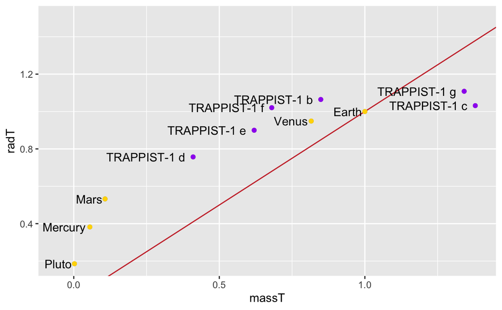

Come nel grafico relativo agli esopianeti è presente la retta sulla quale vediamo posizionarsi la Terra. Ne consegue un’osservazione fondamentale secondo la quale alcuni dei pianeti appartenenti a TRAPPIST-1 siano per certi versi più simili alla Terra di altri vicini a noi come Marte, sul quale si ritiene che in passato fossero presenti microorganismi viventi e che forse continuino ad abitare questo.

## CONCLUSIONE

Quest’ultima assunzione rafforza una delle tesi, ovvero quella relativa alla correlazione tra dimensioni del pianeta ed abitabilità. Va però specificato come i fattori influenti nelle ipotesi di abitabilità non si fermano alle dimensioni del pianeta, bensì siano numerosi e tra questi entrano in gioco alcuni non presenti nel dataset come l’atmosfera, la gravità presente su questi e altri ancora. Negli ultimi anni sono state svolte diverse ricerche a riguardo i cui risultati sembrano lentamente affievolire l’entusiasmo iniziale manifestato da parte della comunità scentifica e della NASA stessa. Alcuni studiosi ritengono infatti che anche i pianeti più miti del sistema possano essere soggetti a un effetto serra fuori controllo e che la nana rossa attorno alla quale orbitano possa essere troppo variabile. Questo tipo di stella infatti è spesso soggetta a brillamenti molto violenti, in grado anche di spazzar via l’atmosfera di pianeti posti a così breve distanza.

L’entusiasmo della comunità scientifica seppur frenato non si è spento ancora. Al momento, nonostante i vari studi, non si hanno certezze riguardo all’inabitabilità dell’intero sistema di TRAPPIST-1. Inoltre la scoperta di nuovi esopianeti avanza a un ritmo talmente elevato, circa 4000 nell’ultimo decennio, da nutrire la speranza di prossime scoperte di pianeti da ritenere in grado di ospitare forme di vita.

## POSSIBILI VISITE

Supponendo in qualche maniera di riuscire a raggiungere il sistema in questione e in particolare il pianeta TRAPPIST-1 c, allora una volta colonizzato qualora questo fosse simile alla Terra ci si potrebbe stanziare. Successivamente organizzare una spedizione verso il pianeta più vicino quindi il pianeta b del sistema distante $4.1*10^{-3}$. Questa distanza è ritenuta percorribile poiché è inferiore al doppio della distanza tra il nostro pianeta e la Luna, e quindi in virtù dell’allunaggio è considerabile copribile come viaggio nello spazio.